# eye_tracking_data

pwilliams

2/5/2019

# Analyzing your Eye Tracker Data in R

The first step to analyzing any of your data in R Studio will be importing your data. Depending on the extension format of your data, this will require different steps. For the purpose of this guide, data will be entered in from SPSS in a .sav format (typical SPSS formatting) and a .edf format (typical format for our eye-tracking data)

**Importing .sav Files**

In order to import a .sav file, you will need to install the *foreign* package:

```r
library(foreign)
```

- If the *foreign* package is not already in your Rstudio library, you will need to install it under the package tab in studio.

Once the package is installed, you now have access to the function we will be using to read in our SPSS .sav file: read.spss(). To read in your file:

```r
df = as.data.frame(read.spss("../../Downloads/shape_35_fdur_means.sav"))
```

```
## re-encoding from CP1252
```

```r
# df = is a simple way of storing our imported data under an easy to remember name (df for data frame)
# The as.data.frame() argument ensures that your document will be read in as a dataframe, making it easier to analyze.
# If the file you are tring to import is not located in your current working directory, you will need to set your working directory within the quotations.
```

Once we have our data in R, we can start to examine it:

```r
head(df) # The head() function allows us to view the first 6 rows of our data frame
```

```
##   SUBJECT          Shape            Similar         Cond       Fix
## 1       1 Normal Preview     Normal Preview      NO MASK 0.8947368
## 2       1   Shape Intact    Similar Letters    similar + 0.9000000
## 3       1   Shape Intact Dissimilar Letters dissimilar + 0.8947368
## 4       1   Shape Denied    Similar Letters    similar - 0.9500000
## 5       1   Shape Denied Dissimilar Letters dissimilar - 1.0000000
## 6       2 Normal Preview     Normal Preview      NO MASK 0.9500000
##     FixDur  SD_FDur  GazeDur TotalTime  SFixDur SDSFixDur      LIW
## 1 286.1765 64.83560 327.6471  370.7059 299.3077  69.00892 2.941176
## 2 278.7778 81.45483 321.9444  404.8889 283.2000  88.66566 2.888889
## 3 256.2353 70.69435 285.1176  296.1765 258.6429  77.54166 3.117647
## 4 266.2632 38.02169 266.2632  266.2632 266.2632  38.02169 3.000000
## 5 284.4737 56.13413 319.6316  348.0000 293.7500  55.47792 3.157895
## 6 304.6316 81.26378 350.1053  409.2105 298.7857  81.92603 3.105263
##     SD_LIW    LIW10 SD_LIW10    SacIn SD_SacIn    AbsLau  SD_ALau
```

[output cut: 20 more lines]

```r
tail(df)# The tails() function allows us to view the last 6 rows of our data frame
```

```
##     SUBJECT          Shape            Similar         Cond       Fix
## 170      34   Shape Denied Dissimilar Letters dissimilar - 1.0000000
## 171      35 Normal Preview     Normal Preview      NO MASK 1.0000000
## 172      35   Shape Intact    Similar Letters    similar + 1.0000000
## 173      35   Shape Intact Dissimilar Letters dissimilar + 1.0000000
## 174      35   Shape Denied    Similar Letters    similar - 0.9500000
## 175      35   Shape Denied Dissimilar Letters dissimilar - 0.9333333
##       FixDur   SD_FDur  GazeDur TotalTime  SFixDur SDSFixDur      LIW
## 170 288.5556  99.53375 372.1667  495.7222 313.1000  84.58585 3.555556
## 171 295.3333 100.32887 386.5000  658.3889 295.6364 116.97117 2.166667
## 172 329.3684 117.22069 354.0000  516.2105 336.6250 126.00152 2.157895
## 173 344.9375 121.78914 373.1250  612.5625 344.0714 112.29183 2.375000
## 174 297.5789 104.98271 363.6842  556.8947 302.8571 122.70531 1.947368
## 175 297.7143  77.66638 391.2143  564.9286 324.1111  86.20534 3.071429
##       SD_LIW    LIW10 SD_LIW10    SacIn SD_SacIn    AbsLau  SD_ALau
```

[output cut: 20 more lines]

```r
glimpse(df) # The glimpse() function provides the class of data within each of our columns (or variables in r)
```

```
## Observations: 175
## Variables: 32
## $ SUBJECT   <fct> 1, 1, 1, 1, 1, 2, 2, 2, 2, 2, 3, 3, 3, 3, 3, 4, 4, 4...
## $ Shape     <fct> Normal Preview, Shape Intact, Shape Intact, Shape De...
## $ Similar   <fct> Normal Preview, Similar Letters, Dissimilar Letters,...
## $ Cond      <fct> NO MASK, similar +, dissimilar +, similar -, dissimi...
## $ Fix       <dbl> 0.8947368, 0.9000000, 0.8947368, 0.9500000, 1.000000...
## $ FixDur    <dbl> 286.1765, 278.7778, 256.2353, 266.2632, 284.4737, 30...
## $ SD_FDur   <dbl> 64.83560, 81.45483, 70.69435, 38.02169, 56.13413, 81...
## $ GazeDur   <dbl> 327.6471, 321.9444, 285.1176, 266.2632, 319.6316, 35...
## $ TotalTime <dbl> 370.7059, 404.8889, 296.1765, 266.2632, 348.0000, 40...
## $ SFixDur   <dbl> 299.3077, 283.2000, 258.6429, 266.2632, 293.7500, 29...
## $ SDSFixDur <dbl> 69.00892, 88.66566, 77.54166, 38.02169, 55.47792, 81...
## $ LIW       <dbl> 2.941176, 2.888889, 3.117647, 3.000000, 3.157895, 3....
## $ SD_LIW    <dbl> 1.919329, 1.875191, 2.117851, 1.885618, 2.007297, 1....
```

[output cut: 19 more lines]

Once we know what levels of data our variables are, we can begin visualizing the data through plots:

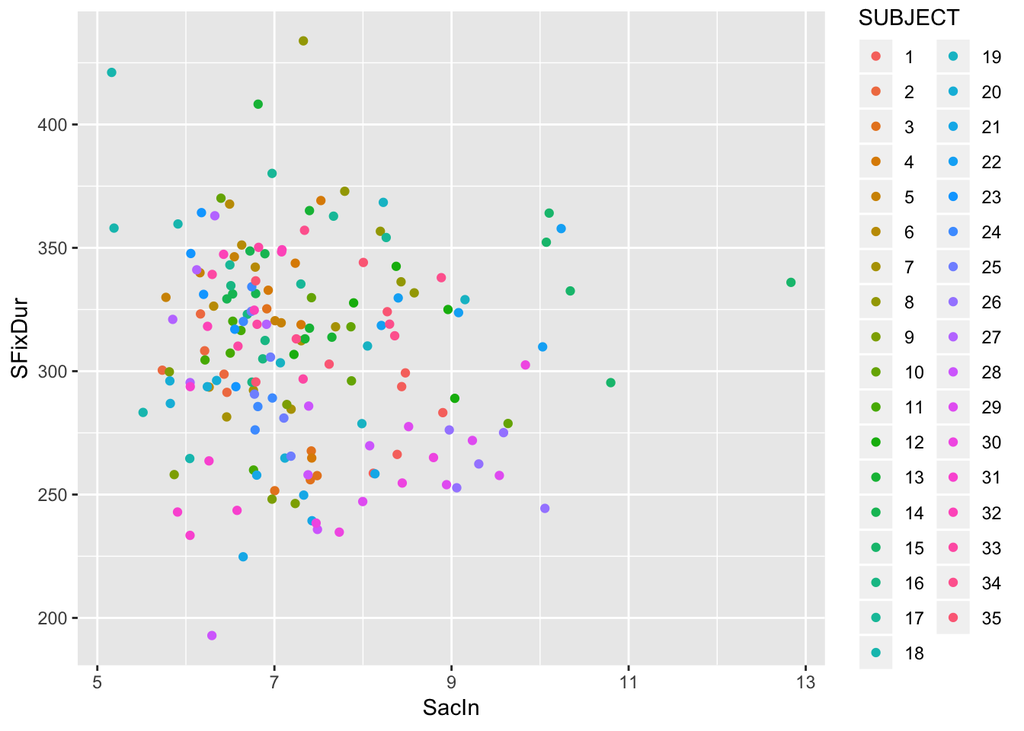

```r
ggplot(df, aes(x=SacIn, y=SFixDur)) +
  geom_point(aes(color=SUBJECT))
```